# 1. Page View Time Series Visualizer

## 1.1 About

This project is my second project working with sample data. This is part of the [freeCodeCamp Data Analysis with Python Certification](https://www.freecodecamp.org/learn/data-analysis-with-python/). For this project I will visualize time series data using a line chart, bar chart, and box plots. I will use Pandas, Matplotlib, and Seaborn to visualize a dataset containing the number of page views each day on the freeCodeCamp.org forum from 2016-05-09 to 2019-12-03. I will analyze the patterns in visits and identify yearly and monthly growth.

## 1.2 Execution

```python
%%shell
jupyter nbconvert --to html "/content/drive/MyDrive/Colab Notebooks/time_series_visualizer/time_series_visualizer.ipynb"
```

```
[NbConvertApp] Converting notebook /content/drive/MyDrive/Colab Notebooks/time_series_visualizer/time_series_visualizer.ipynb to html
[NbConvertApp] Writing 874673 bytes to /content/drive/MyDrive/Colab Notebooks/time_series_visualizer/time_series_visualizer.html
```

### 1.2.1 Import Necessary Libraries and Data

When importing the data, we will set the index to the date column. We will use `df.head(5)` to see if the data has been imported correctly.

```python
import matplotlib.pyplot as plt
import pandas as pd
import seaborn as sns
from pandas.plotting import register_matplotlib_converters
register_matplotlib_converters()
```

```python
from google.colab import drive
drive.mount('/content/drive')
```

```python
# Import Data
df = pd.read_csv('/content/drive/MyDrive/Colab Notebooks/time_series_visualizer/fcc-forum-pageviews.csv', delimiter = ',').set_index('date')
df.head(5)
```

| date | value |
| --- | --- |
| 2016-05-09 | 1201 |
| 2016-05-10 | 2329 |
| 2016-05-11 | 1716 |
| 2016-05-12 | 10539 |
| 2016-05-13 | 6933 |

### 1.2.2 Cleaning the Data

Clean the data by filtering out days when the page views were in the top 2.5% of the dataset or bottom 2.5% of the dataset.

```python
df = df [
  (df['value'] < df['value'].quantile(0.975)) &
  (df['value'] > df['value'].quantile(0.025))
]
```

### 1.2.3 Create a `draw_line_plot` Function

Create a `draw_line_plot` function that uses Matplotlib to draw a line chart. The title should be Daily freeCodeCamp Forum Page Views 5/2016-12/2019. The label on the x axis should be Date and the label on the y axis should be Page Views.

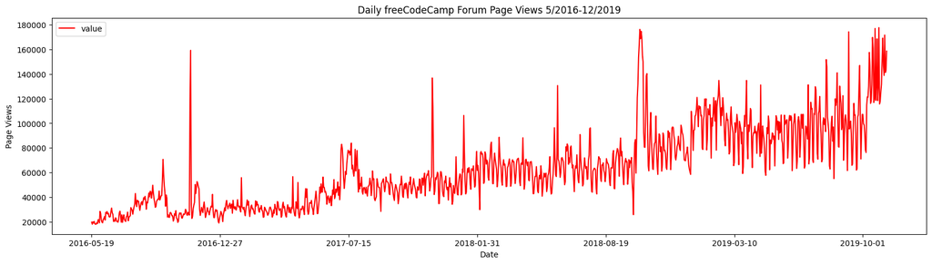

```python
def draw_line_plot():
    # Draw line plot
    df.plot.line(color = 'red', figsize = (20,5))
    plt.xlabel("Date")
    plt.ylabel("Page Views")
    plt.title("Daily freeCodeCamp Forum Page Views 5/2016-12/2019")

draw_line_plot()
```

### 1.2.4 Create a `draw_bar_plot` Function

Create a `draw_bar_plot` function that draws a bar chart. It should show average daily page views for each month grouped by year. The legend should show month labels and have a title of Months. On the chart, the label on the x axis should be Years and the label on the y axis should be Average Page Views.

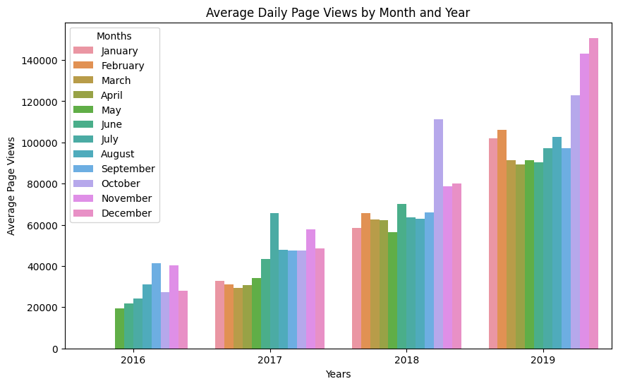

```python
def draw_bar_plot():
    # Copy and modify data for monthly bar plot
    df_bar = df.copy()
    df_bar.reset_index(inplace=True)
    df_bar['Years'] = pd.DatetimeIndex(df_bar['date']).year
    df_bar['Months'] = pd.DatetimeIndex(df_bar['date']).month_name()
    df_bar = df_bar.groupby(['Years', 'Months'])['value'].mean().reset_index()

    # Draw bar plot
    plt.figure(figsize=(10, 6))
    plot = sns.barplot(data = df_bar, x = 'Years', y = 'value', hue = 'Months', hue_order = ('January', 'February', 'March', 'April', 'May', 'June', 'July',
                'August', 'September', 'October', 'November', 'December'))
    plt.xlabel('Years')
    plt.ylabel('Average Page Views')
    plt.title('Average Daily Page Views by Month and Year')
    sns.move_legend(plot, 'upper left')
draw_bar_plot()
```

### 1.2.5 Create a `draw_box_plot` Function

Create a `draw_box_plot` function that uses Seaborn to draw two adjacent box plots. These box plots should show how the values are distributed within a given year or month and how it compares over time. The title of the first chart should be Year-wise Box Plot (Trend) and the title of the second chart should be Month-wise Box Plot (Seasonality). Make sure the month labels on bottom start at Jan and the x and y axis are labeled correctly. The boilerplate includes commands to prepare the data.

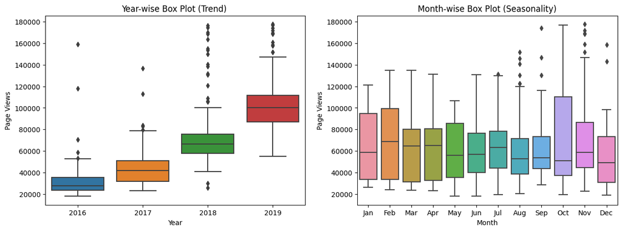

```python
def draw_box_plot():
    # Prepare data for box plots (this part is done!)
    df_box = df.copy()
    df_box.reset_index(inplace=True)
    df_box['date'] = pd.to_datetime(df_box['date'])
    df_box['year'] = [d.year for d in df_box['date']]
    df_box['month'] = [d.strftime('%b') for d in df_box['date']]

    # Draw box plots (using Seaborn)
    fig, axes = plt.subplots(1, 2, figsize=(15, 5))
    sns.boxplot(data = df_box, x = 'year', y = 'value', ax = axes[0])
    axes[0].set_xlabel('Year')
    axes[0].set_ylabel('Page Views')
    axes[0].set_title('Year-wise Box Plot (Trend) ')

    sns.boxplot(data = df_box, x = 'month', y = 'value', order = ['Jan', 'Feb', 'Mar', 'Apr', 'May', 'Jun', 'Jul',
                'Aug', 'Sep', 'Oct', 'Nov', 'Dec'], ax = axes[1])
    axes[1].set_xlabel('Month')
    axes[1].set_ylabel('Page Views')
    axes[1].set_title('Month-wise Box Plot (Seasonality)')
draw_box_plot()
```

## 1.3 Conclusion

Through this project, I was able to practice various plotting skills. The charts/graphs provide a more appealing way to visualize the data at hand.